# Sampling Distribution of the Mean

## This week in tgs data science

**Clinic visit:** Does a transfusion during surgury for colorectal cancer result in poorer outcomes? (The investigator is interested in discovering if there is a causal relationship, not just an association.)

## Hands-on

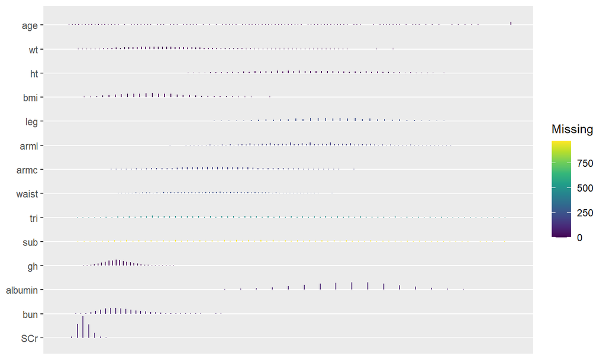

## Hands-on

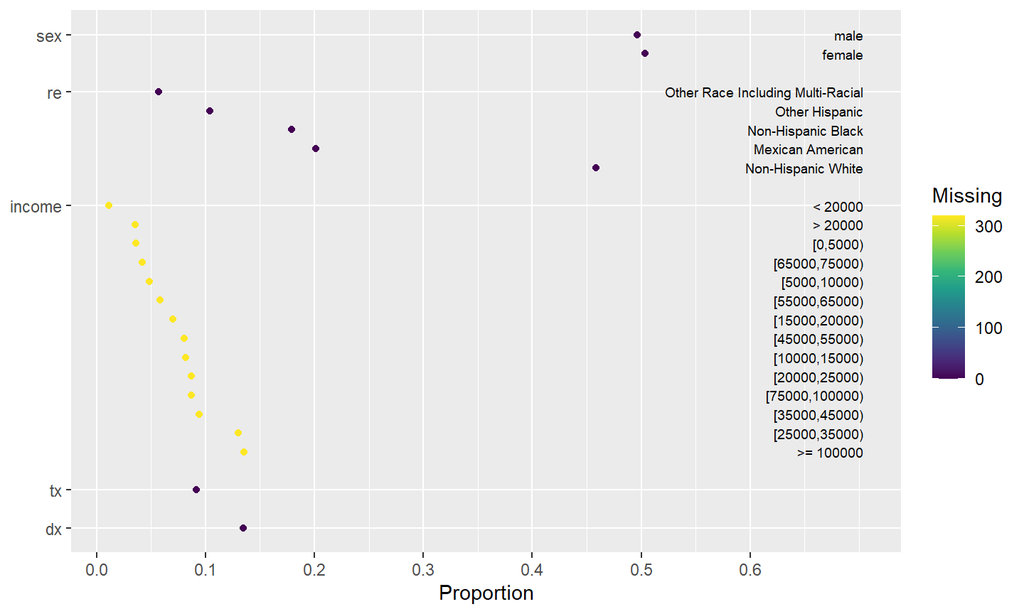

## Hands-on

| Variable | Missing | Mean | SD |
| --- | --- | --- | --- |
| Age (years) | 0 | 44.3 (43.8, 44.8) | 20.6 |
| Weight (kg) | 0 | 79.4 (78.8, 79.9) | 21.9 |
| Standing Height (cm) | 0 | 167.0 (166.8, 167.3) | 10.3 |
| Body Mass Index (kg/m^2) | 0 | 28.3 (28.2, 28.5) | 7.0 |
| Upper Leg Length (cm) | 231 | 38.4 (38.3, 38.5) | 3.9 |
| Upper Arm Length (cm) | 179 | 36.9 (36.8, 36.9) | 2.8 |

## Hands-on

| Variable | Missing | Median | IQR |
| --- | --- | --- | --- |
| Age (years) | 0 | 43.8 (43.1, 44.6) | [25.7, 61.3] |
| Weight (kg) | 0 | 76.3 (75.7, 76.9) | [64.0, 91.1] |
| Standing Height (cm) | 0 | 166.6 (166.2, 166.9) | [159.6, 174.5] |
| Body Mass Index (kg/m^2) | 0 | 27.3 (27.1, 27.5) | [23.4, 31.9] |
| Upper Leg Length (cm) | 231 | 38.4 (38.3, 38.5) | [36.0, 41.0] |
| Upper Arm Length (cm) | 179 | 36.8 (36.7, 37.0) | [35.0, 38.8] |

## Hands-on

> Generate **95%** confidence intervals for median SCr and bun

## Hands-on

> Generate a 95% confidence intervals for median SCr and bun
1. Which estimate of \(F_X\) did you use?
2. Did you create a confidence interval via simulation? analytically?

## Hands-on

> Generate a 95% confidence intervals for median SCr and bun
1. Which estimate of \(F_X\) did you use?  
   **Options:** ECDF (bootstrap), gamma via mm or mle, normal via mm or mle, mixture of normals, etc.
2. Did you create a confidence interval via simulation? analytically?

## Hands-on

> Generate a 95% confidence intervals for median SCr and bun

#### Bootstrap & simulation solution

```r
R <- 2000
medians <- rep(NA, R)
for(i in 1:R){
  s <- sample(nhgh$SCr, length(nhgh$SCr), replace = TRUE)
  medians[i] <- median(s, na.rm = TRUE)
}
alpha <- 0.05
medians %>% quantile(c(alpha/2, 1-alpha/2))
```

```
##  2.5% 97.5%
##  0.82  0.83
```

## Today: Sampling distribution of the mean Chapter 9

## Sampling distribution of the mean

> All of the tools that we’ve learned for generating the sampling distribution apply to the mean.

> **However**, the mean has some special properties that give us a **short cut** for generating the sampling distribution.

Look for the pattern in the sampling distribution of the mean for 4 very different distributions.

## Distribution 1 or 4: Normal

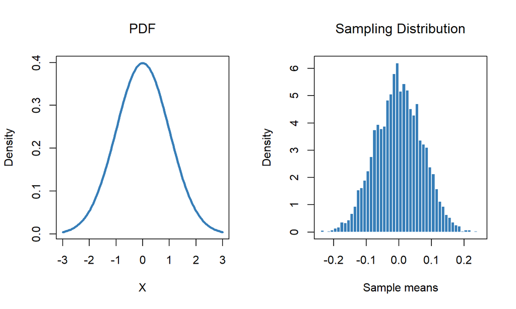

## Distribution 2 or 4: Exponential

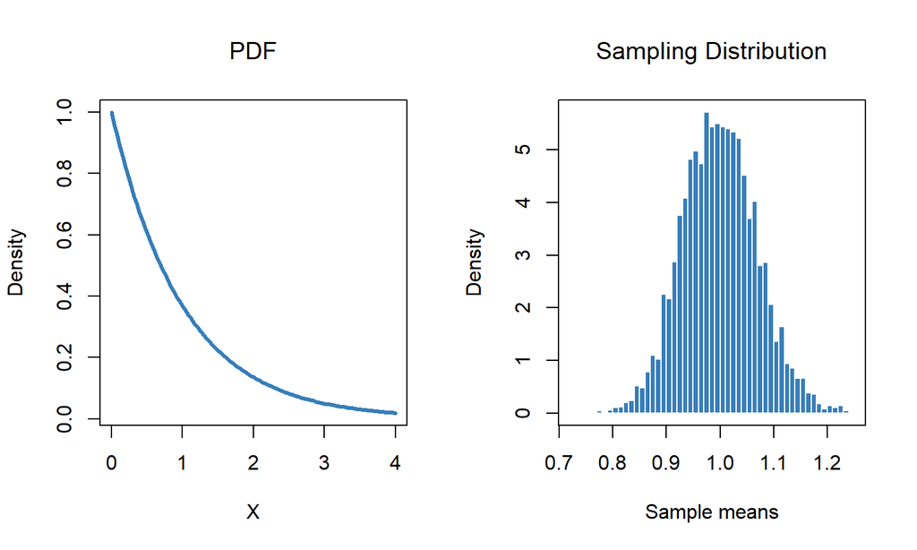

## Distribution 3 or 4: Mixture of Normals

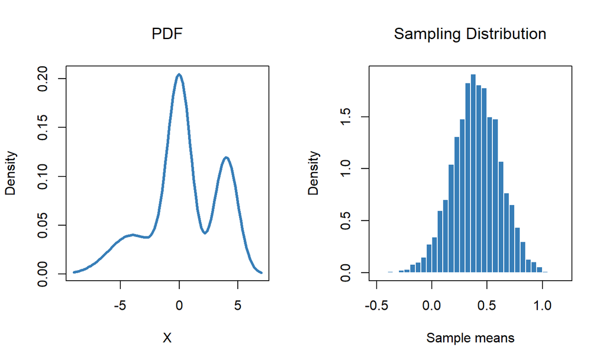

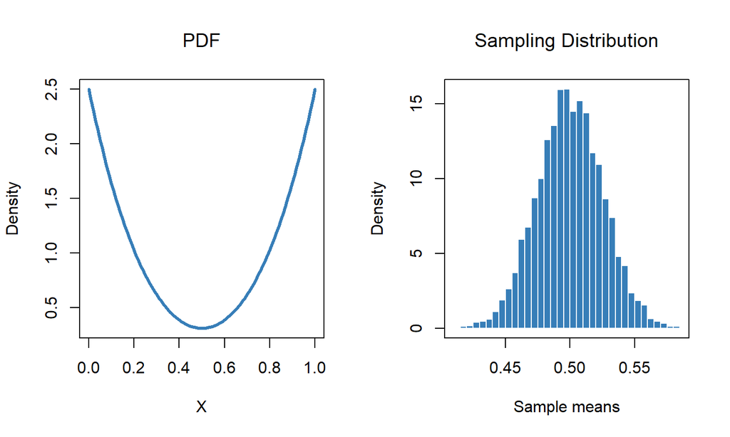

## Sampling distribution of the mean

> **Pattern:** The sampling distribution of the mean seems to be symmetric and bell shaped, **(almost)** regardless of the distribution.

## Sampling distribution of the mean

> **Pattern:** The sampling distribution of the mean seems to be symmetric and bell shaped, **(almost)** regardless of the distribution.

> **Precise statement:** If \(X_1\), \(X_2\), \(\dots\) are independent random variables, all having the same distribution which has mean \(m\) and variance \(v^2\), then \[ Z = \frac{\bar{X}_N - m}{\frac{v}{\sqrt{N}}} = \sqrt{N}\frac{\bar{X}_N - m}{v} \] converges in distribution to a standard normal random variable.

## Central Limit Theorem

### Key phrases

> If \(X_1\), \(X_2\), \(\dots\) are **independent** random variables, all having the **same distribution** which **has mean** \(m\) and **variance** \(v^2\), \[ Z = \frac{\bar{X}_N - m}{\frac{v}{\sqrt{N}}} = \sqrt{N}\frac{\bar{X}_N - m}{v} \] **converges** in distribution to a standard normal random variable.
1. Independent
2. Identically distributed
3. Mean and variance exist
4. Sample size large enough for convergence

## Where does the CLT come from?

> If \(X_1\), \(X_2\), \(\dots\) are independent random **Normal** variables with mean \(\mu\) and variance \(\sigma^2\), then

\[ \sum_{i=1}^N X_i \sim N(N\mu, N\sigma^2)\] and

\[\bar{X}_N = \frac{1}{N}\sum_{i=1}^N X_i \sim N\left(\mu, \frac{\sigma^2}{N}\right) \]

## Where does the CLT come from? (continued)

After standardization,

\[ \frac{\bar{X}_N - \mu}{\sqrt{\frac{\sigma^2}{N}}} \sim N\left(0, 1\right) \]

which simplifies to

\[ \sqrt{N}\frac{\bar{X}_N - \mu}{\sigma} \sim N\left(0, 1\right) \]

## Where does the CLT come from? (continued)

> If \(X_1\), \(X_2\), \(\dots\) are independent random **Normal** variables with mean \(\mu\) and variance \(\sigma^2\), then \[ \sqrt{N}\frac{\bar{X}_N - \mu}{\sigma} \sim N\left(0, 1\right) \] **regardless** of the size of **N**.

## Where does the CLT come from? (continued)

> It can be shown that \[ \sqrt{N}\frac{\bar{X}_N - \mu}{\sigma}\] has an approximate standard normal distribution **regardless of the distribution** so long as  
> 1. the distribution mean and variance exist  
> 2. the sample size is large enough  
> 3. the data \(X_1\), \(X_2\), \(\ldots\), \(X_N\) are independent and identically distributed.

## Short-cut for the sampling distribution of the mean

\[\text{If } Z \text{ is a standard normal draw, then } \\ Z\frac{v}{\sqrt{N}} + m \\ \text{ is an approximate draw from the sampling distribution of }\\ \bar{X}_N \\ \text{when the conditions of the CLT are met.}\]

## Short-cut for the sampling distribution of the mean

\[\text{If } Z_{\alpha} \text{ is a quantile of the standard normal, then} \\ Z_{\alpha}\frac{v}{\sqrt{N}} + m \\ \text{ is an approximate quantile of the sampling distribution of }\\ \bar{X}_N\\ \text{when the conditions of the CLT are met.}\]

## Short-cut for the sampling distribution of the mean

\[\text{Consequently, }\\ \left(Z_{\alpha/2}\frac{v}{\sqrt{N}} + m, Z_{1-\alpha/2}\frac{v}{\sqrt{N}} + m \right) \\ \text{ is an approximate confidence interval of }\\ \bar{X}_N\\ \text{when the conditions of the CLT are met.}\]

## Short-cut for the sampling distribution of the mean

> **Question:** What if one doesn’t know what \(m\) and \(v\) are?

## Short-cut for the sampling distribution of the mean

> **Question:** What if one doesn’t know what \(m\) and \(v\) are?

One approach is to plug-in the sample estimates, \(\bar{X}\) for \(m\) and \(s\) for \(v\):

\[ \left(Z_{\alpha/2}\frac{s}{\sqrt{N}} + \bar{X}_N,\ Z_{1-\alpha/2}\frac{s}{\sqrt{N}} + \bar{X}_N \right) \\ \text{ is an approximate confidence interval of }\\ \bar{X}_N\]

## Short-cut for the sampling distribution of the mean

> **Question:**What if one doesn’t know what \(m\) and \(v\) are?

One approach is to plug-in the sample estimates, \(\bar{X}\) for \(m\) and \(s\) for \(v\). **Often**, when the plug-in solution is implemented, the standard normal quantiles are replaced with \(t\) quantiles:

\[ \left(t_{\alpha/2, N-1}\frac{s}{\sqrt{N}} + \bar{X}_N,\ t_{1-\alpha/2, N-1}\frac{s}{\sqrt{N}} + \bar{X}_N \right) \\ \text{ is an approximate confidence interval of }\\ \bar{X}_N\]

## Short-cut for the sampling distribution of the mean

**Lingo:** \(Z\) intervals use quantiles from the standard normal. \(t\) intervals use quantiles from the \(t_{N-1}\) distribution.

> **Why \(t\) intervals?** To capture additional uncertainty related to estimating the standard deviation.

> **Why does the author of our text not care about \(t\) intervals?** For large \(N\) the difference between \(Z\) and \(t_{N-1}\) is very small.

## Short-cut for the sampling distribution of the mean

| N | \(Z_{0.025}\) | \(t_{0.025, N-1}\) |
| --- | --- | --- |
| 50 | -1.959964 | -2.0095752 |
| 100 | -1.959964 | -1.984217 |
| 500 | -1.959964 | -1.9647294 |
| 1000 | -1.959964 | -1.9623415 |

## More notation & lingo

Because the standard normal and \(t\) distributions are symmetric

\[Z_{1-\alpha/2} = - Z_{\alpha/2}\ \text{ and } \\ t_{1-\alpha/2,\ df} = - t_{\alpha/2,\ df},\]

The simplified expression of the confidence interval is

\[ \bar{X} \pm Z_{\alpha/2}\frac{s}{\sqrt{N}}\\ \bar{X} \pm t_{\alpha/2, N-1}\frac{s}{\sqrt{N}}\]

## In R

```r
# Without short cut
Hmisc::getHdata(nhgh)

R <- 2000
means <- rep(NA, R)
mean_mle <- mean(nhgh$SCr, na.rm = TRUE)
sd_mle <- sd(nhgh$SCr, na.rm = TRUE)

for(i in 1:R){
  s <- rnorm(length(nhgh$SCr), mean = mean_mle, sd = sd_mle)
  means[i] <- mean(s)
}
alpha <- 0.05
t0 <- quantile(means, c(alpha/2, 1-alpha/2))

# With short cut

t1 <- t.test(nhgh$SCr)
```

## In R

```r
t0
```

```
##      2.5%     97.5%
## 0.8684173 0.8890255
```

```r
t1
```

```
##
##  One Sample t-test
##
## data:  nhgh$SCr
## t = 161.6, df = 6705, p-value < 2.2e-16
## alternative hypothesis: true mean is not equal to 0
## 95 percent confidence interval:
##  0.8679683 0.8892849
## sample estimates:
## mean of x
## 0.8786266
```

## Interval plots

```r
out <- data.frame(
    p=NA
  , l=NA
  , u=NA
  , lab = c("mle","t interval")
  , stringsAsFactors = FALSE
)
out[1,1:3] <- c(mean(nhgh$SCr, na.rm = TRUE), t0)
out[2,1:3] <- c(t1$estimate, t1$conf.int)
tgsify::plot_point_ci(1,2,3,4,out)
```

## Interval plots

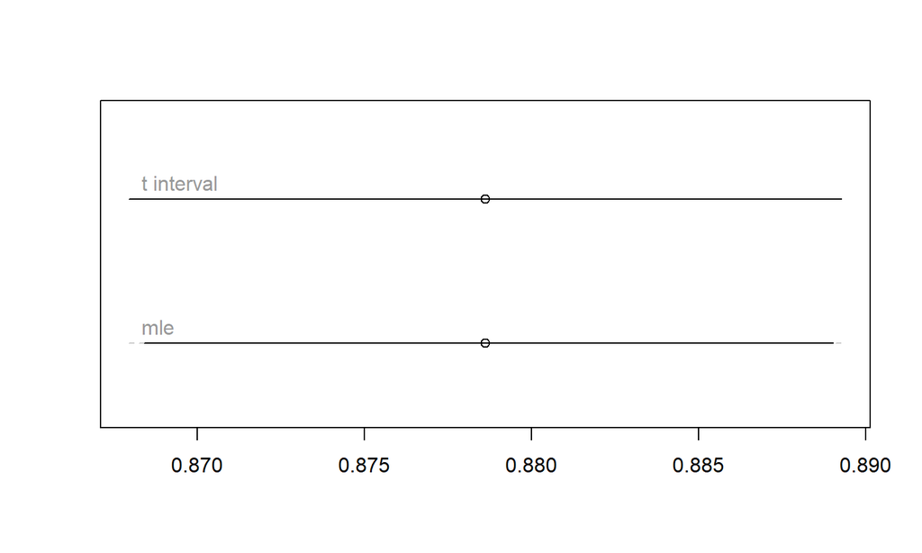

## Any summary measure that can be framed as a sample average can use the CLT short-cut

> **Example:** In the population of infant mother pairs at Baystate Medical Center, what is the proportion that smoke during pregnancy?  
> **Data**: 189 births at Baystate Medical Center in Springfield, MA during 1986 (Hosmer and Lemeshow,1989 Appendix I)

|  | Freq. | Percent |
| --- | --- | --- |
| nonsmoker | 115 | 60.85 |
| smoker | 74 | 39.15 |
| Total | 189 | 100.00 |

## Any summary measure that can be framed as a sample average can use the CLT short-cut

\[ \text{If } X_i = \left\{\begin{array}{ll} 1 & Smoker \\ 0 & Nonsmoker \end{array} \right.\\ \text{Then }\hat{p} = \frac{1}{N}\sum_{i = 1}^N X_i = \bar{X}_N \text{ is the sample proportion}\]

## Proportion and the CLT short-cut

> **What is the sampling distribution of \(\hat{p}\)?**

**CLT trick**

\[X_i \sim \text{Bernoulli}(p) \\ E[X_i] = p\\ V[X_i] = p(1-p)\\ \ \\ \text{So, } \hat{p} \overset{\text{approx}}{\sim} N\left(p, \sqrt{\frac{p(1-p)}{N}}\right) \\ \text{Plug-in, } \hat{p} \overset{\text{approx}}{\sim} N\left(\hat{p}, \sqrt{\frac{\hat{p}(1-\hat{p})}{N}}\right) \\ \]

## Confidence interval for proportion using CLT short cut

\[ \hat{p} \pm Z_{\alpha/2}\sqrt{\frac{\hat{p}(1-\hat{p})}{N}} \]

## Back to the example

> **Example:** In the population of infant mother pairs at Baystate Medical Center, what is the proportion that smoke during pregnancy?  
> **Data**: 189 births at Baystate Medical Center in Springfield, MA during 1986 (Hosmer and Lemeshow,1989 Appendix I)

|  | Freq. | Percent |
| --- | --- | --- |
| nonsmoker | 115 | 60.85 |
| smoker | 74 | 39.15 |
| Total | 189 | 100.00 |

> What is the 95% confidence interval for the proportion of smokers in this patient population?

## In R

```r
# By hand
phat <- 74/189
s <- sqrt(phat*(1-phat)/189)
phat + c(1,-1)*qnorm(0.05/2)*s
```

```
## [1] 0.3219487 0.4611201
```

```r
# R command
prop.test(74, 189, correct = FALSE)$conf.int
```

```
## [1] 0.3247720 0.4626181
## attr(,"conf.level")
## [1] 0.95
```

## Lingo

Confidence intervals calculated with the CLT short cut are often call **Wald** intervals.

- For small samples, Wald CIs for the proportion tend to be too narrow
- Another problem with Wald CIs: can extend below 0 & above 1.

## Aside

> Though not as widely known, **Wilson** or **score** CIs have better coverage than Wald, especially for smaller samples and proportions near 0 or 1.

## Recap

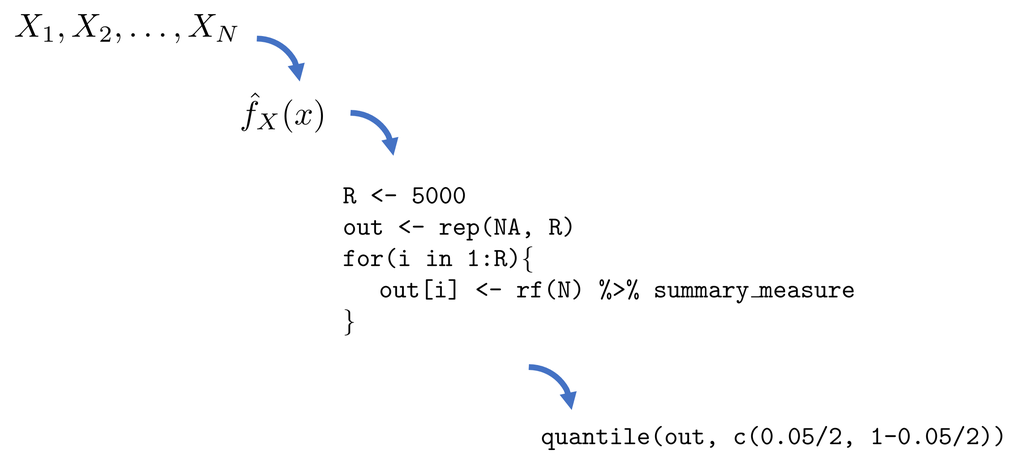

## Recap

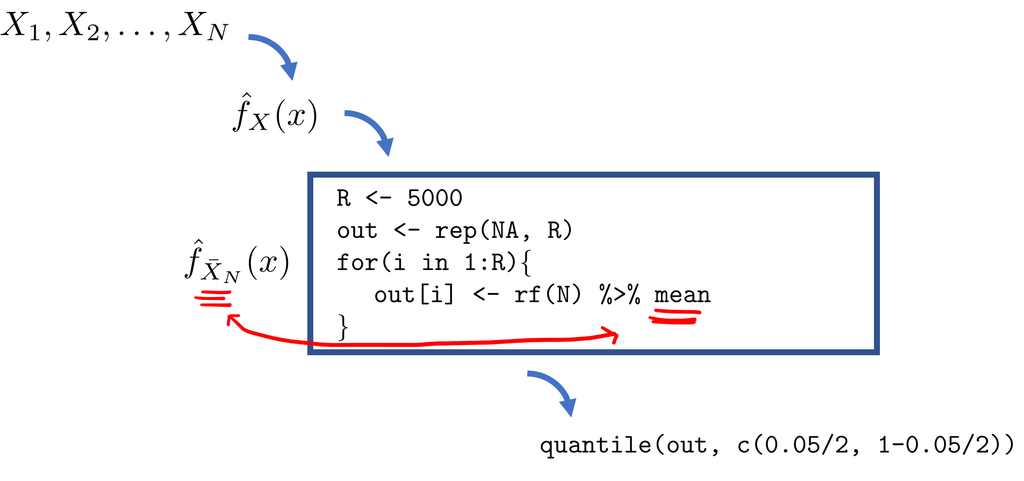

## Recap

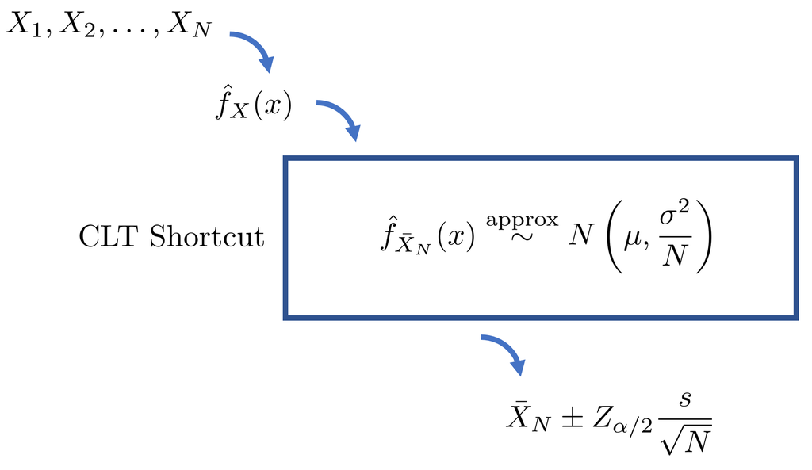

## Recap

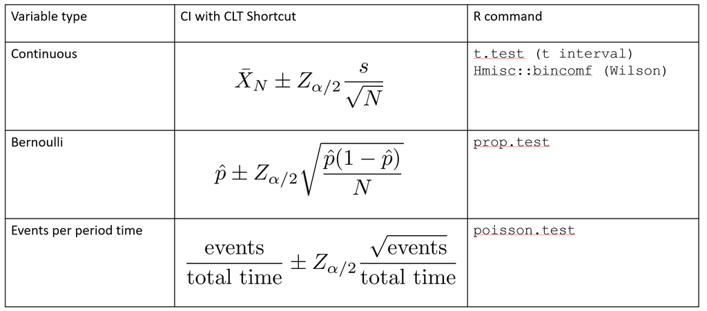

## Hands on

Generate a 95% confidence interval for the proportion of respondents that reported “Non-Hispanic Black” as their race/ethnicity.

```r
Hmisc::getHdata(nhgh)
```

## Hands on

```r
require(tgsify)
Hmisc::getHdata(nhgh)
nhgh$re %>% table(useNA = "always")

# Old fashioned
phat <- mean(nhgh$re == "Non-Hispanic Black")
R <- 5000
out <- rep(NA, R)
for(i in 1:R){
  s <- rbinom(nrow(nhgh),1,phat)
  out[i] <- mean(s)
}

hist(out)
alpha <- 0.05
quantile(out, c(alpha/2, 1- alpha/2))
```

## Hands on

```r
# CLT by hand
phat + c(1, -1)*qnorm(alpha/2)*sqrt(phat*(1-phat)/nrow(nhgh))


# CLT by canned command
n_successes <- sum(nhgh$re == "Non-Hispanic Black")
n_trials <- nrow(nhgh)
prop.test(n_successes, n_trials)
```

## Hands on

Generate a 95% confidence interval for the proportion of respondents that reported an income less than $20,000.